# Humanitarian Funding Flows Analysis

Donor Profile: Switzerland, Government of

Author

AI Generated Analysis based on [OCHA Finantial Tracking Service Data API](https://fts.unocha.org/). Beware of data limitations and potential hallucinations! Thanks for reporting any [issues here](https://github.com/Edouard-Legoupil/ftsAnalysis/issues/new) – View all Reports

## Executive Summary

The Government of Switzerland has emerged as a rapidly expanding humanitarian donor, with funding commitments soaring from under $1 million in 2022 to nearly $288 million projected in 2025. This dramatic scale-up underscores Switzerland’s growing role as a key partner for large-scale and impactful humanitarian initiatives. Fundraisers should prioritize early engagement and develop proposals that demonstrate strategic alignment with Swiss priorities, focusing on interventions with scalable, sustainable outcomes to capture this expanding funding envelope.

Switzerland’s funding is distinctly concentrated in specific earmarking categories, with over $215 million channeled into its primary priority area, followed by a secondary focus receiving approximately $73 million. Other earmarking types attract considerably less investment, reflecting a clearly defined strategic focus. Prospective applicants are advised to tailor proposals to the dominant earmarking types favored by Switzerland to maximize funding prospects and avoid areas with limited allocation.

A pronounced preference is evident in contribution modalities, with nearly 99.6% of total funding directed through a single flow type. Aligning program design with the characteristics of this predominant funding channel—whether it relates to direct implementation, capacity building, or emergency response—is crucial for securing Swiss government support. While the minor funding allocated to alternative flow types may offer advocacy opportunities, the dominant modality should be the primary target for proposal alignment.

Sectoral funding patterns further reveal Switzerland’s prioritization of select high-impact clusters, with the largest number of funding flows concentrated in one leading sector and substantial engagement in three others. Proposals that explicitly align with these top-funded sectors and demonstrate clear impact potential are well-positioned to attract Swiss funding. There is also scope for innovation in moderately funded clusters to tap into emerging opportunities within Switzerland’s humanitarian portfolio.

In summary, Switzerland’s humanitarian funding profile signals a donor with sharply focused priorities, a preference for specific funding mechanisms, and an accelerating commitment to scale. Tailored, strategically aligned proposals addressing key sectors and funding modalities stand to benefit most from this expanding donor opportunity.

## Funding History

The funding data for the Government of Switzerland shows a dramatic increase in contributions over the four-year period from 2022 to 2025. In 2022, total funding was approximately 556 thousand USD, rising modestly to around 4.4 million USD in 2023. However, the most significant growth occurs thereafter, with funding reaching over 17.5 million USD in 2024 and skyrocketing to nearly 288 million USD in 2025. This sharp upward trend highlights an increasing commitment by Switzerland to humanitarian funding, especially visible between 2023 and 2025, where contributions multiply by more than 65 times. For humanitarian proposal writers, this suggests a strong and growing donor interest from Switzerland, making it a promising source for large-scale project funding, particularly in the medium to long term. To capitalize on this trend, proposals should emphasize alignment with Switzerlands strategic priorities and demonstrate the potential for impactful, scalable interventions. Given the steep increase projected for 2025, it is also advisable to prepare proposals well in advance to match the timelines of large disbursements. Highlighting successful outcomes and sustainable impacts could further attract sustained funding from this growing donor.

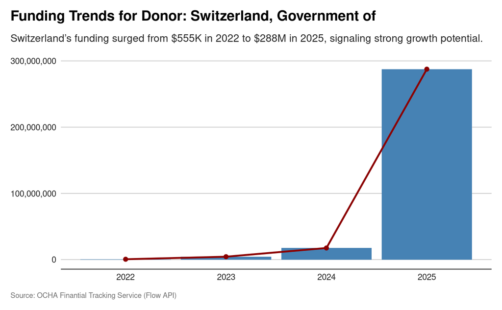

## Earmaking Approach

The Government of Switzerland’s funding distribution across different earmarking types reveals a clear prioritization pattern. The largest share of funding, approximately 215 million USD, is dedicated to the first earmarking type, indicating a strong preference or priority area. This significantly surpasses the second category, which receives about 73 million USD, showing the next highest but markedly lower investment. The third earmarking type sees minimal allocation, with just over 1.2 million USD, highlighting very limited focus or restricted funding opportunities in that area. The fourth category receives nearly 21 million USD, representing a moderate level of engagement. For humanitarian proposal writers, these figures suggest that aligning proposals with the primary earmarking category favored by the Swiss government could improve funding prospects. The marked difference in funding between the top two categories and the others also implies strategic value in targeting areas where Switzerland has shown robust financial commitment. Additionally, understanding that some earmarking types are minimally funded can help in managing expectations and focusing efforts where resources are more likely to be available. This insight encourages proposals to emphasize alignment with Swiss priorities to maximize the chance of securing support.

[figure not shown]

## Contribution Type

The funding distribution from the Government of Switzerland shows a significant concentration in one flow type. Specifically, out of the total funds disbursed, approximately 99.6% (308.9 million USD) is allocated to the second flow type, while only about 0.4% (1.1 million USD) goes to the first flow type. This sharp disparity highlights a strategic preference or priority for one category of funding, which could reflect the government’s focus on specific types of humanitarian activities or regions. For humanitarian proposal writers, this suggests alignment with the dominant flow type could increase chances of securing Swiss government funding. Understanding what the second flow type representssuch as direct project support, infrastructure development, or emergency responseis essential to tailor proposals accordingly. Additionally, the relatively small allocation in the first flow type indicates potential gaps or opportunities for advocacy, especially if emerging needs align with that category. Proposals emphasizing innovative approaches within the heavily funded flow type may also resonate, given the large-scale investment, but there remains value in demonstrating complementary activities linked to the lesser-funded category to broaden support. Overall, the data points to a concentrated funding approach, underscoring the importance of targeted proposal development that closely matches Swiss government priorities.

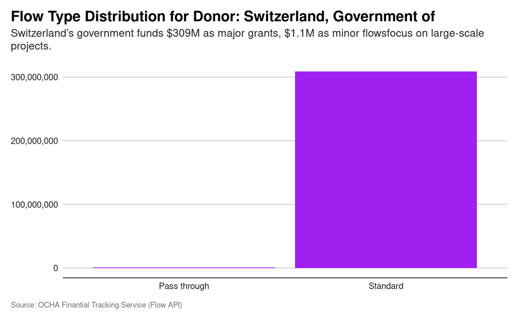

## Sectoral Prioritisation

[figure not shown]